# Marketing Mix Modelling (MMM) with Google Meridian — Bikes (Demo)

**Goal:** Estimate *incremental* contribution of paid media channels to weekly sales and derive budget recommendations under constraints.

**Important:** This is a **demonstration dataset**. Results are illustrative. This workflow is for **decision support / incrementality**, not KPI forecasting.

## 1) Setup & Imports

## 2) Load data + basic data contract

Expected columns:

- `Week` (weekly date)
- `sales` (weekly revenue or sales KPI)
- media spend columns (e.g., `tv_spend`, `facebook_spend`, etc.)

|  | Week | sales | branded_search_spend | nonbranded_search_spend | facebook_spend | print_spend | ooh_spend | tv_spend | radio_spend |
| --- | --- | --- | --- | --- | --- | --- | --- | --- | --- |
| 0 | 7/23/17 | 58850.0 | 1528.8 | 463.32 | 802.620 | 0 | 0 | 0 | 0 |
| 1 | 7/30/17 | 62050.0 | 1575.6 | 468.00 | 819.312 | 0 | 0 | 0 | 0 |
| 2 | 8/6/17 | 59388.0 | 1544.4 | 477.36 | 749.034 | 0 | 0 | 0 | 0 |
| 3 | 8/13/17 | 56964.0 | 1528.8 | 468.00 | 741.468 | 0 | 0 | 0 | 0 |
| 4 | 8/20/17 | 53460.0 | 1560.0 | 458.64 | 811.200 | 0 | 0 | 0 | 0 |

|  | mean | std | min | max |
| --- | --- | --- | --- | --- |
| sales | 68107.553558 | 19608.831323 | 29088.000 | 113762.880 |
| branded_search_spend | 2033.680231 | 902.962242 | 1375.920 | 7800.000 |
| nonbranded_search_spend | 402.383740 | 200.049791 | 229.320 | 1093.693 |
| facebook_spend | 1015.262797 | 453.045170 | 660.231 | 3900.000 |
| print_spend | 376.923077 | 487.533935 | 0.000 | 1500.000 |
| ooh_spend | 188.461538 | 391.834536 | 0.000 | 1000.000 |
| tv_spend | 278.846154 | 788.512244 | 0.000 | 2500.000 |
| radio_spend | 523.076923 | 1033.906896 | 0.000 | 3000.000 |

## 3) Quick EDA (sanity checks)

Keep it light: trend/seasonality and spend mix.

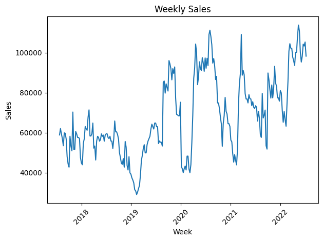

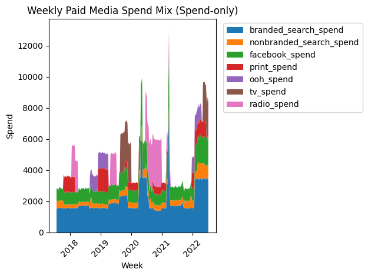

## 4) Baseline controls (trend + seasonality)

We add simple time controls that are safe for MMM to avoid a negative baseline. This is a common issues when trend/seasonality (and other drivers) are missing.

|  | trend_t | sin_52 | cos_52 | sin_26 | cos_26 |
| --- | --- | --- | --- | --- | --- |
| 0 | 0.0 | -0.343277 | -0.939234 | 0.644835 | 0.764322 |
| 1 | 1.0 | -0.453615 | -0.891198 | 0.808521 | 0.588467 |
| 2 | 2.0 | -0.557384 | -0.830255 | 0.925541 | 0.378647 |
| 3 | 3.0 | -0.653080 | -0.757289 | 0.989141 | 0.146972 |
| 4 | 4.0 | -0.739319 | -0.673355 | 0.995649 | -0.093185 |